# Análisis de Datos y Predicción de Eventos Cardíacos

# Introducción

## ¿Qué es un “evento cardíaco”?

Al hablar de un evento cardíaco nos referimos a una serie de problemas que pueden presentarse en caso de que el corazón no reciba suficiente sangre para su funcionamiento. Al suceder esto, el corazón puede dañarse, lo que a su vez causa lo que se conoce como un Síndrome Coronario Agudo (por ejemplo, un ataque cardíaco).

Una de las causas mas comunes de los SCA es el desprendimiento o acumulación de placa en las arterias, lo que pueden crear coágulos de sangre en las mismas al desprenderse o bien bloquear gran parte del flujo de sangre.

## ¿Cuál es el objetivo del predictor?

El objetivo de este predictor es complementar el juicio de los doctores a cargo de la guardia del hospital, asistiendo en la toma de decisiones rápidas en cuanto concierne a un paciente en riesgo de sufrir un evento cardíaco.

# Análisis de Datos

## Distribución de los datos

### Edad

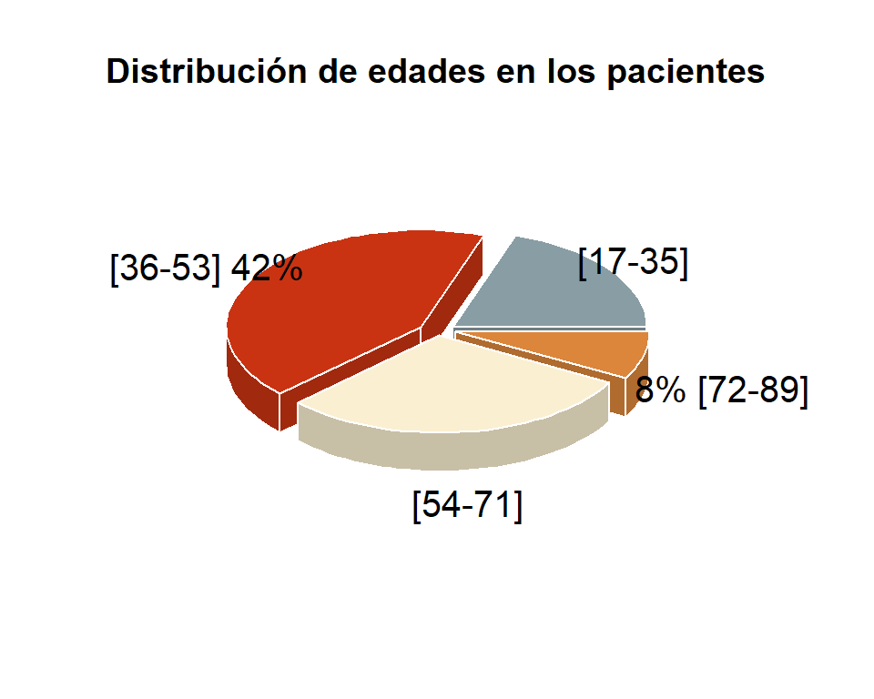

### Género

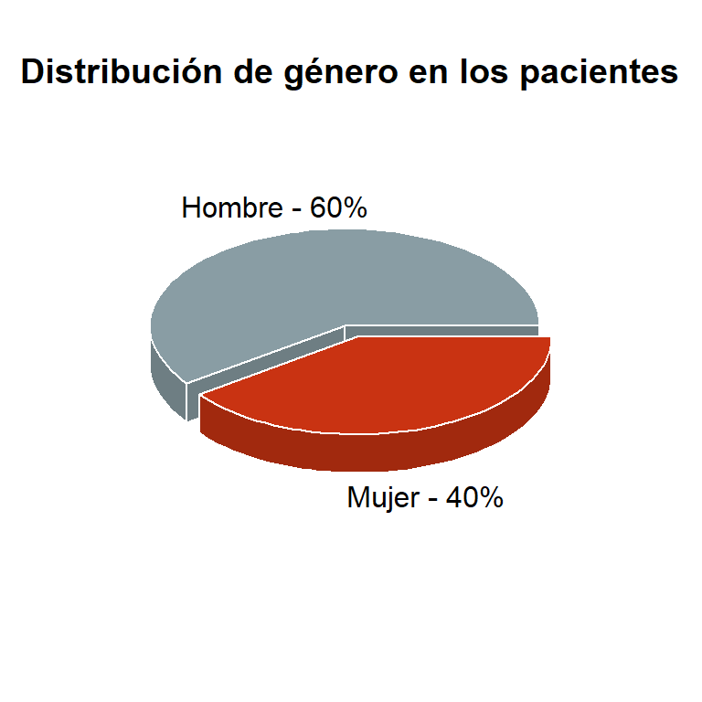

## Incidencia de Evento

### Sobre el total

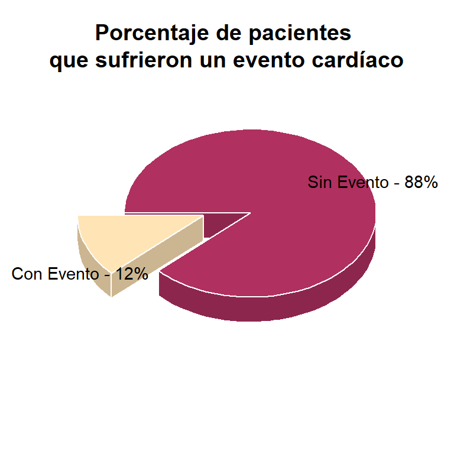

### Dependiendo de la Edad

#### Entre 17 y 35 años

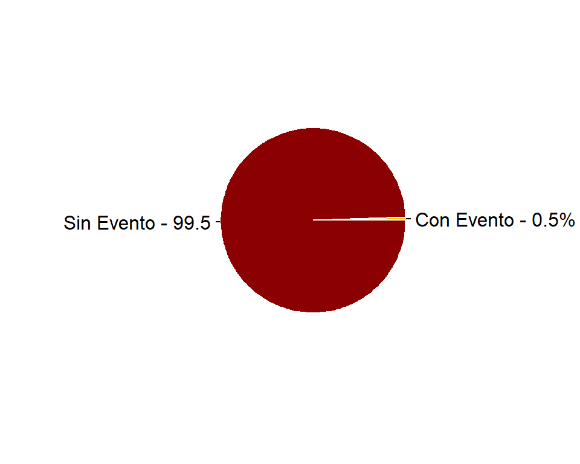

#### Entre 36 y 53 años

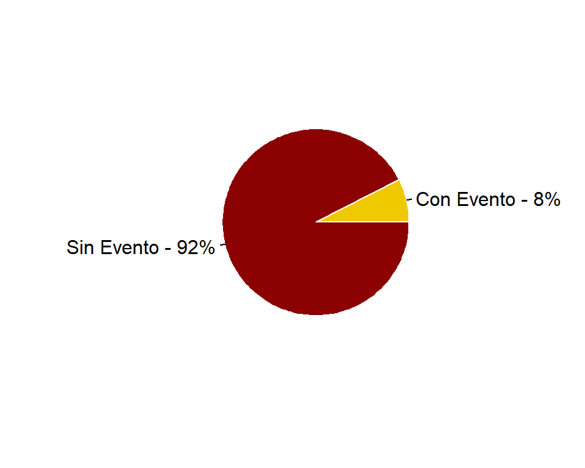

#### Entre 54 y 71 años

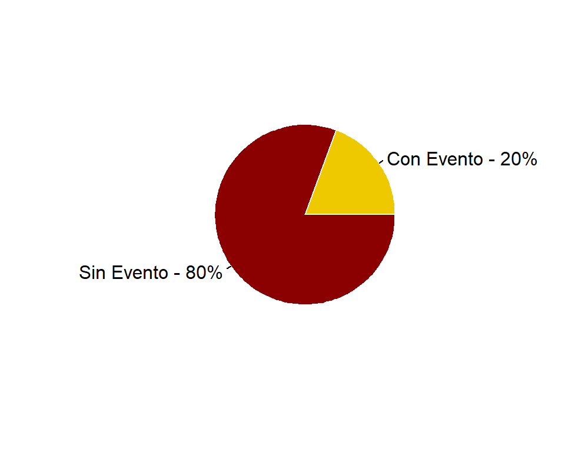

#### Entre 72 y 89 años

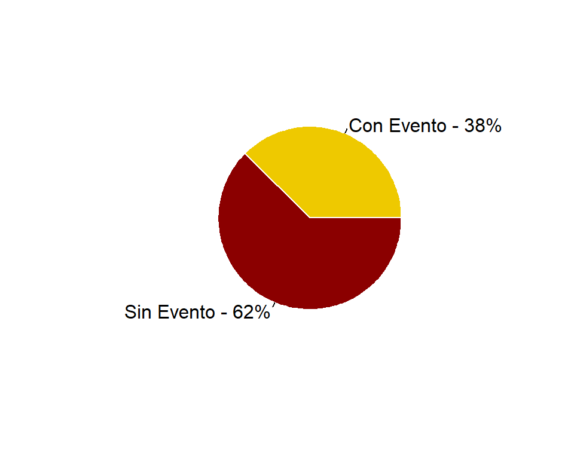

### Dependiendo de Género

#### Mujeres

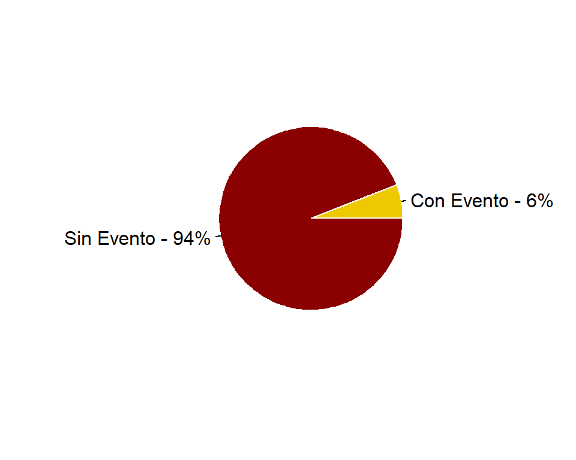

#### Hombres

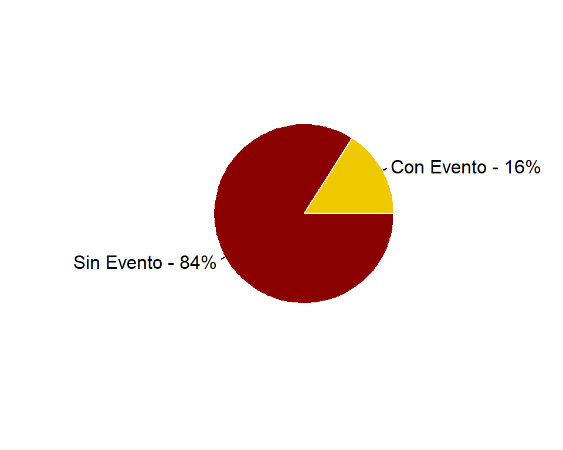

## Determinación de Variables

### ¿Qué variables consideramos como un síntoma?

- Síntomas Asociados (SA)
- Sme Anginoso (SmeA)
- Presenta Dolor Actual (PDA)

Al investigar acerca de las causas de un evento cardíaco, se llegó a la conclusión de que estos eran los efectos de riesgo más frecuentes. La información se basa en artículos como Enfermedades del corazón en las mujeres: Comprende los síntomas y factores de riesgo. (s.f.). Recuperado de http://https://www.mayoclinic.org/es-es/diseases-conditions/heart-disease/in-depth/heart-disease/art-20046167

### ¿Qué variables consideramos como un factor de riesgo?

- Antecedentes Familiares (AHF)
- Tabaquismo (TBQ)
- Dislipemia (DLP)
- Diabetes (DBT)
- Hipertensión Arterial (HTA)
- Síndrome Coronario Agudo previo o Historia de Revascularización (SCApHR)
- Obesidad (OBES)

Para la selección de los síntomas de eventos cardíacos se recurrió a diferentes páginas web, por ejemplo,Síntomas de un ataque cardíaco (s.f.). Recuperado de http://https://espanol.womenshealth.gov/heart-disease-and-stroke/heart-disease/heart-attack-and-women/heart-attack-symptoms. Los mencionados previamente fueron los más comunes.

## Análisis de Síntomas

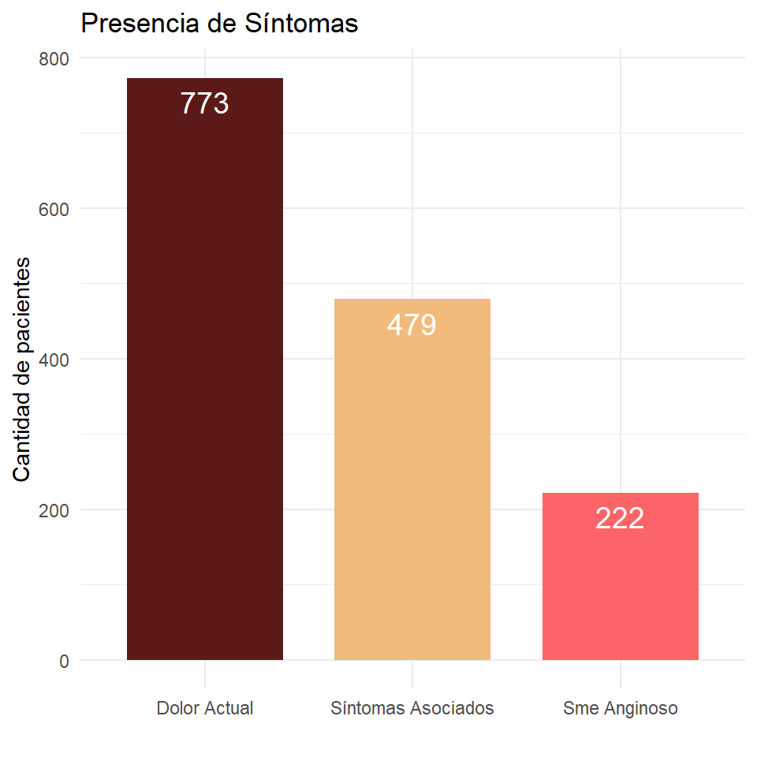

Se puede ver la cantidad de pacientes que presentaron cada uno de los síntomas. Es evidente que el más común por un gran margen, es el dolor actual.

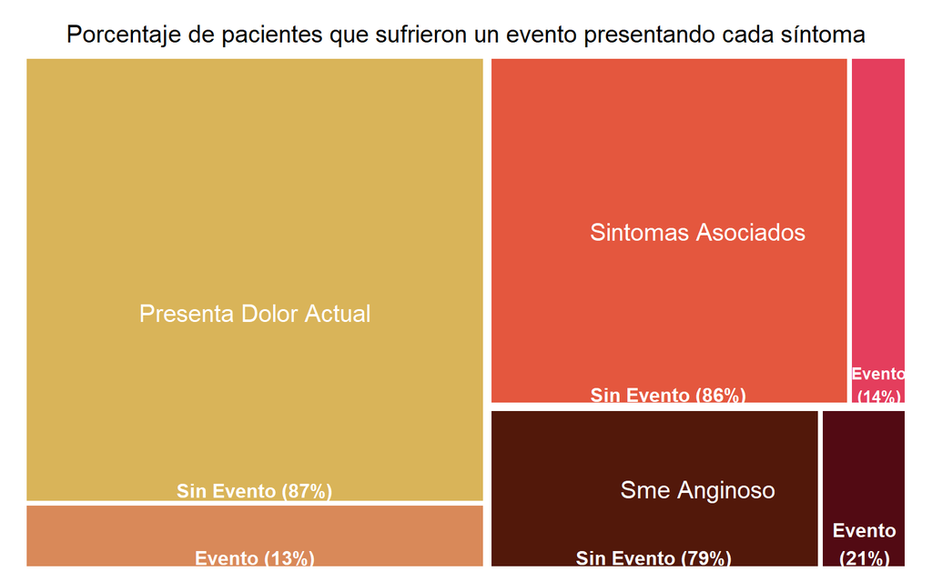

Se pueden observar las presencias relativas de los distintos síntomas, y dentro de cada uno el porcentaje de pacientes que padecieron de eventos cardíacos y presentaron del mismo.

## Análisis de Factores de Riesgo

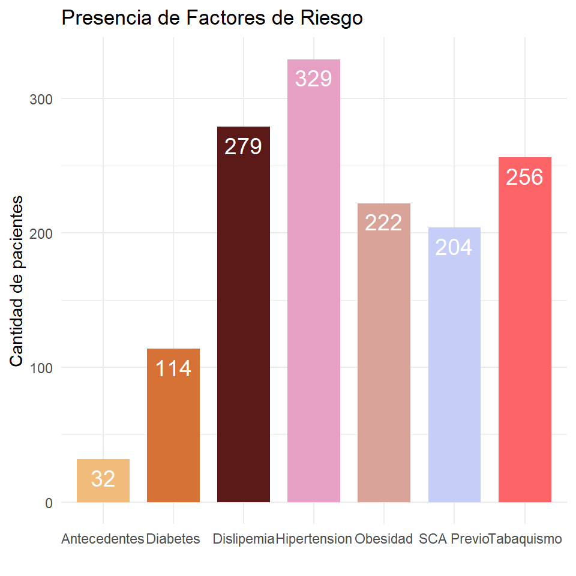

Se pueden obserar las presencias de todos los factores de riesgo. De todos modos, el gráfico no toma en cuenta la posibilidad de que un paciente pueda tener más de un factor de riesgo. La incidencia de cada factor por su cuenta se estudia en el siguiente gráfico; y en el próximo, el efecto sobre la probabilidad de sufrir un evento de la cantidad de factores que tiene un paciente.

[interactive chart not shown]

En este gráfico se analiza la cantidad de pacientes que sufren de cada factor de riesgo. Dentro del bloque del factor se observa el porcentaje de personas que padecen de este, que tuvieron un evento y cuántos no.

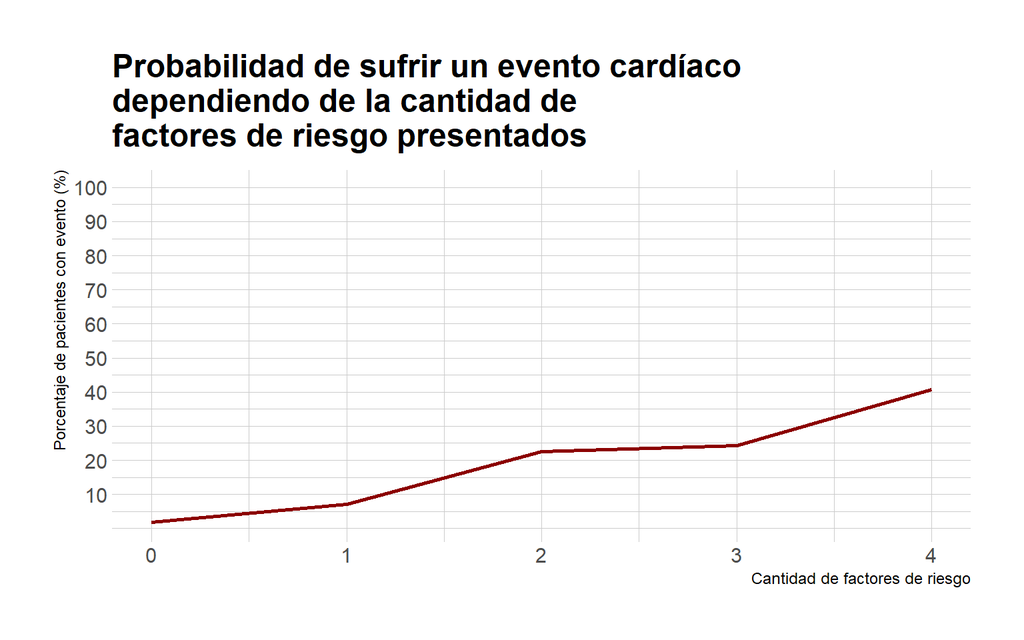

El eje horizontal del gráfico representa la cantidad de factores de riesgo para un evento cardiaco, y el eje vertical representa el porcentaje de pacientes con esa cantidad de factores que tuvieron un evento.

Los datos proporcionados no eran suficientes para llegar a conclusiones precisas respecto a la presencia de 5 o más factores de riesgo, por lo que estos pacientes no fueron incluidos en el gráfico.

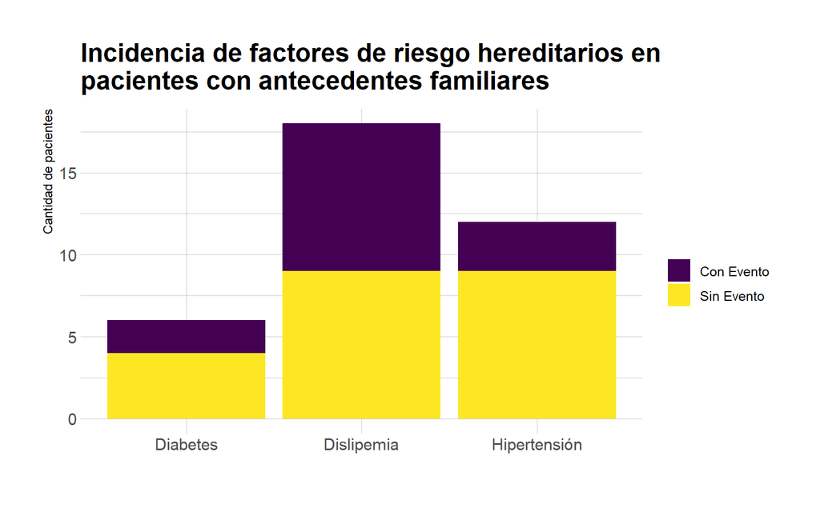

# Conclusiones

Luego de analizar todos los datos, podemos llegar a algunas conclusiones interesantes:

- La mayoría de los pacientes estudiados no sufrieron de eventos cardíacos, por lo que los datos obtenidos son más útiles para determinar cuando un paciente *no* está teniendo un evento.
- El porcentaje de pacientes con edades entre 17 y 35 que tuvieron eventos es casi inexistente. Por el contrario, este porcentaje crece de manera significativa al aumentar las edades de los pacientes estudiados. Esto se vuelve especialmente evidente al ver que casi un 40% de los pacientes entre 72 y 89 años sufrieron de un evento.
- De todos modos, entre los datos estudiados, solo el 8% de los pacientes tenían edades de entre 72 y 89 años, por lo que los datos generados por este análisis pueden no aplicarse en su totalidad a este grupo demográfico.
- Dentro de todos los pacientes que van a la guardia por temor a estar sufriendo un evento cardíaco, la gran mayoría presenta **Dolor Actual**. A pesar de esto, solo un 13% de estas personas está teniendo un evento real, por lo que es esencial obtener información adicional sobre el paciente antes de tomar una decisión.
- Los tres factores de riesgo más comunes en los pacientes que se presentan en la guardia son la **Hipertensión**, la **Dislipemia** y el **Tabaquismo** pero el factor con mayor cantidad relativa de evento es la presencia de **Antecedentes Familiares**.

# Predictor

## Construcción

### Selección de Variables

Se utilizaron dos herramientas para ayudar en la selección de variables que conformaran el predictor: el método *Stepwise* y una Matriz de Correlación.

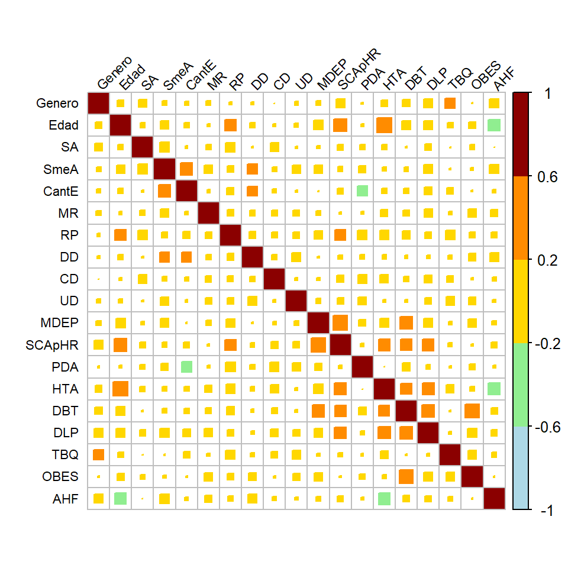

Podemos ver que los factores de riesgo están fuertemente correlados entre sí, especialmente los *Diabetes*, la *Hipertensión* y la *Dislipemia*. También se puede ver la relación que tiene la *Edad* con la Hipertensión, y la *Obesidad* con los Diabetes.

Basándonos en los resultados de ambos métodos, determinamos la lista final de variables:

- **MDEP:** Mismo dolor evento previo
- **TBQ:** Tabaquismo
- **DBT:** Diabetes
- **MR:** Modifica respiración posición
- **OBES:** Obesidad
- **SmeA:** Sme Anginoso
- **AHF:** Antecedentes Familiares
- **HTA:** Hipertensión Arterial
- **Género**
- **Edad**

### Modelo de predicción

Se decidió utilizar un modelo de regresión logística para el desarrollo del predictor. Las regresiónes logísticas son particularmente útiles para predicciones categóricas, como es el caso aquí.

## Evaluación de calidad

### Testing

Utilizando un 30% del dataset no incluido al construir el predictor, evaluamos la precisión del mismo:

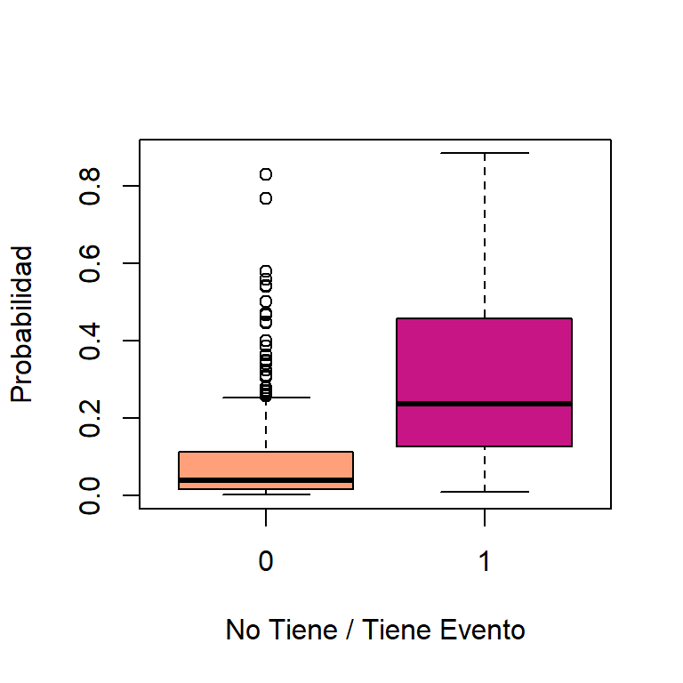

El hecho de que ambas cajas en el gráfico anterior no se sobrepongan de forma significativa significa que el modelo creado es bueno.

Podemos observar también, que el predictor es más preciso al determinar cuando un paciente *no* está teniendo un evento, un **verdadero negativo**, a cuando si lo esta teniendo. Esto puede atribuirse al hecho de que en la base de datos utilizada solo 12% de los individuos padecieron de eventos.

Utilizando el boxplot como referencia y considerando el objetivo del predictor, elegimos algunos valores como *threshold* al evaluar la calidad del modelo. Determinamos que la principal necesidad del predictor en este caso es poder determinar con certeza si un paciente está sufriendo de un evento cardíaco, por sobre la necesidad de saber si *no* lo está haciendo. Por esta razón los valores elegidos serán cercanos al 0.

### Matriz de Confusión

Basándonos en el límite elegido anteriormente, realizamos una matriz de confusión para ilustrar las ventajas y desventajas de usar este modelo. La matriz muestra la cantidad de falsos negativos y falsos positivos predecidos dentro del grupo de prueba.

El primer valor de *threshold* utilizado fue **0.1**:

```
## Confusion Matrix and Statistics
##
##           reference
## prediction   0   1
##          0 189   7
##          1  76  29
##
##                Accuracy : 0.7243
##                  95% CI : (0.6701, 0.774)
##     No Information Rate : 0.8804
##     P-Value [Acc > NIR] : 1
##
##                   Kappa : 0.2838
##
##  Mcnemar's Test P-Value : 8.395e-14
##
##             Sensitivity : 0.7132
##             Specificity : 0.8056
##          Pos Pred Value : 0.9643
##          Neg Pred Value : 0.2762
##              Prevalence : 0.8804
##          Detection Rate : 0.6279
##    Detection Prevalence : 0.6512
##       Balanced Accuracy : 0.7594
##
##        'Positive' Class : 0
##
```

Como se puede observar, según esta matriz el nivel de precisión es de aproximadamente 0.7, y, tal como fue mencionado, la mayor cantidad de errores se presenta en los falsos positivos, mientras que hay muy pocos falsos negativos.

El segundo valor de *threshold* que evaluamos fue **0.05**:

```
## Confusion Matrix and Statistics
##
##            reference
## prediction1   0   1
##           0 146   3
##           1 119  33
##
##                Accuracy : 0.5947
##                  95% CI : (0.5369, 0.6506)
##     No Information Rate : 0.8804
##     P-Value [Acc > NIR] : 1
##
##                   Kappa : 0.1955
##
##  Mcnemar's Test P-Value : <2e-16
##
##             Sensitivity : 0.5509
##             Specificity : 0.9167
##          Pos Pred Value : 0.9799
##          Neg Pred Value : 0.2171
##              Prevalence : 0.8804
##          Detection Rate : 0.4850
##    Detection Prevalence : 0.4950
##       Balanced Accuracy : 0.7338
##
##        'Positive' Class : 0
##
```

En este caso, el porcentaje de falsos negativos es de mucho menor que el anterior. Por el otro lado, los falsos positivos subieron a casi un 50%. Creemos que este modelo puede ser más útil en ayudar a la toma de decisiones de un médico.

### Curva AUROC

La curva AUROC evalúa la precisión de un predictor evaluando la ocurrencia de falsos positivos, buscando así una relación balanceada entre ambos. Cuanto más alto el valor AUC es, mejor es el modelo.

Primero, utilizamos el *threshold* automático de la función, que evalúa a cada probabilidad proporcionada por la regresión logística puntualmente:

```
## [1] 0.829717
```

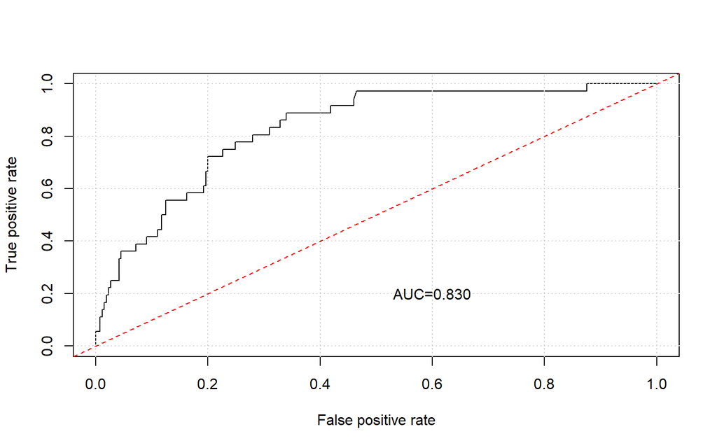

Luego, utilizamos los resultados evaluados con el *threshold* 0.1:

```
## [1] 0.7593816
```

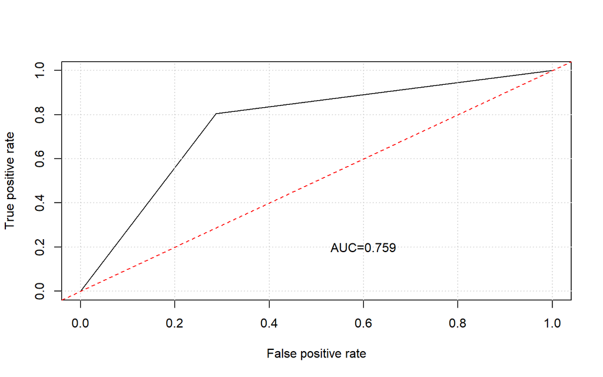

Finalmente, utilizamos el valor 0.05:

```
## [1] 0.733805
```

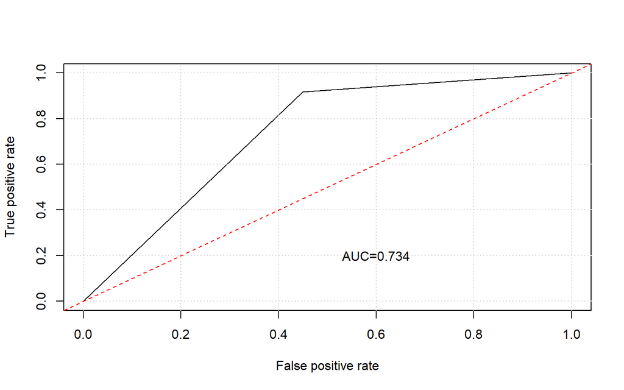

Vale recordar que el valor AUC refiere a una relación balanceada entre los falsos negativos y los falsos positivos, algo que no es necesariamente ideal en todos los casos. Este predictor busca asegurar que un paciente que esté teniendo un evento cardíaco reciba el tratamiento necesario, y tiene prioridades acorde a ese objetivo. Por esta razón, no es conveniente decidir qué modelo utilizar basado únicamente en los resultados de esta curva.